# CALIDAD DE CONEXIÓN

14/12/2021

# CALIDAD DE CONEXIÓN DE INTERNET EN 5 DISTRITOS DE LIMA

# 1. Introducción

### Interés para la audiencia

Debido a lo acontecido en los últimos dos años por la pandemia (coronavirus), el acceso a Internet se convirtió en uno de los servicios básicos importantes para la sociedad, y a la vez uno de los más difíciles de conseguir para gran parte de la población a causa de los precios, accesibilidad de la red, entre otros.

### Información que se desea aportar

Lo que buscamos aportar con esta investigación es información acerca de la cantidad de personas que tuvieron acceso a Internet en 5 distritos de Lima, las dificultades y facilidades que presentaron, cuales fueron sus molestias, y así a la vez hacer una comparación acerca de que distritos fueron los menos perjudicados, sobre todo en la época en la que la pandemia estuvo más fuerte y se presentaron muchas dificultades.

### ¿Por qué elegimos este tema?

La elección de nuestro estudio esta justificado por:

- Es **importante** porque el uso de Internet es prácticamente diario en la mayoría de los hogares, se usa para diferentes actividades como por ejemplo: estudiar desde casa, trabajo remoto, navegar en las redes, etc; por lo tanto, tener una buena conexión es esencial para poder realizar nuestras actividades sin problemas.
- Es **factible** ya que usaremos una base de datos, la cual lo obtendremos de una encuesta enfocada en los 5 distritos elegidos, la cual tendrá preguntas relevantes acerca de la calidad de Internet en los hogares de cada una de las personas encuestadas.
- Es **específico** porque nos enfocaremos en solo 5 distritos, los cuales son los de una mejor calidad de vida por lo que guardan una relación. Estos son: San Isidro, San Borja, San Juan de Miraflores, Barranco y Santiago de Surco.

# 2. Objetivos

### **Objetivos General**

Analizar que tan buena es la conexión a Internet, en 5 puntos distintos de la capital de Lima, y que tan bueno es el servicio ofrecido por las diferentes empresas hoy en día.

### **Objetivos específicos**

1. Comparar cual es la diferencia de calidad de conexión entre uno y otro distinto.
2. Analizar si las empresas dan la cantidad de Internet que ofrecen o si es que este es mucho menos o mucho más.
3. Determinar si los ciudadanos estarían conformes con el servicio que se les ofrece, o estarían en total desacuerdo.
4. Analizar si las compañías que ofrecen Internet solucionan los problemas con efectividad y de la mejor manera para sus clientes.

[output not shown]

# **4. Variables**

### **Variables de Encuesta ‘CALIDAD DE CONEXIÓN’**

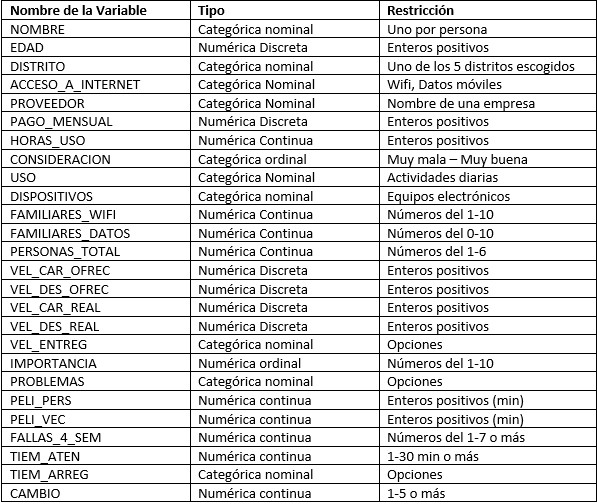

# **5. Descriptores numéricos y gráficos**

### **EDADES**

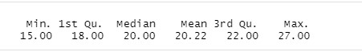

Aquí queremos ver cual es la edad promedio de las personas que responden nuestra encuesta ya que podemos deducir que son las interesadas acerca de la investigación.

### **Variables Categóricas**

#### **Variable DISTRITO**

Para esta variable se realiza un diagrama de barras, para observar aproximadamente cuantas personas respondieron de cada distrito.

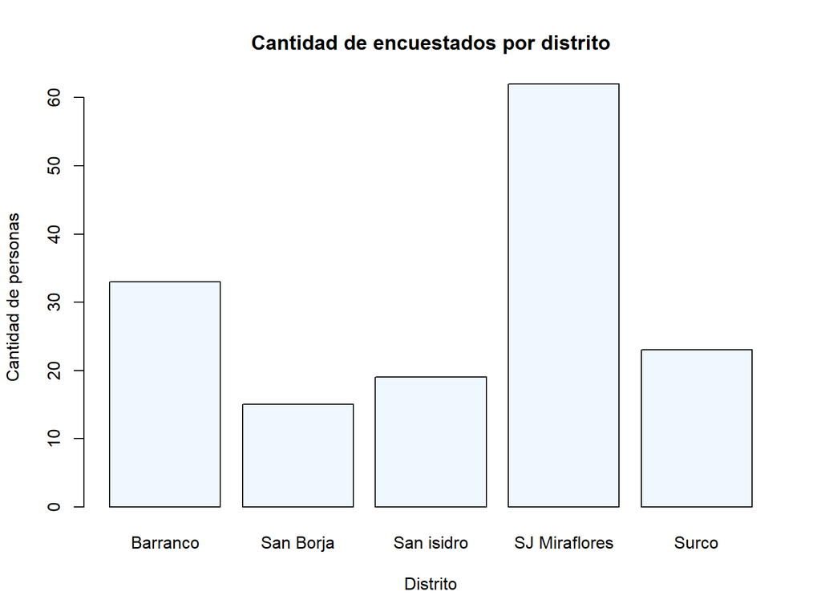

**Observaciones**

La gráfica de barras nos revela que tenemos más encuestados de San Juan de Miraflores, pero de igual forma hay encuestados de los otros distritos, los cuales irán subiendo más adelante.

#### *Variable ACCESO_A_INTERNET:*

Para esta variable se realizará un gráfico de barras para visualizar cuántas personas usan WIFI o datos móviles en prepago y postpago.

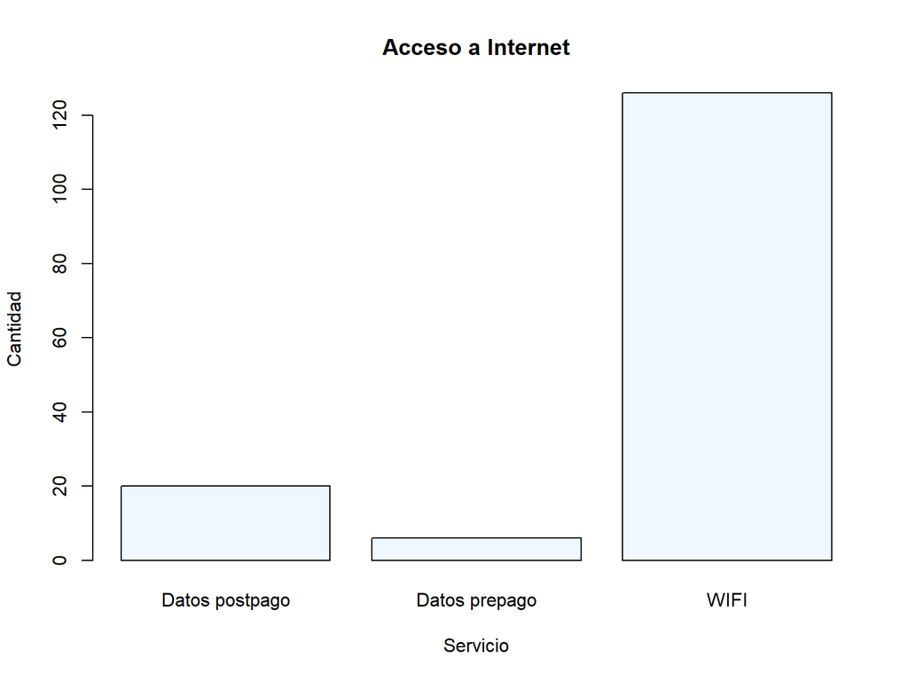

**Observaciones**

En el gráfico se puede observar claramente que la mayoría usa WIFI en sus hogares.

#### *Variable PROVEEDOR:*

En esta variable se realizará una gráfica de barras para conocer cual es el proveedor más usado que ofrece el servicio a Internet.

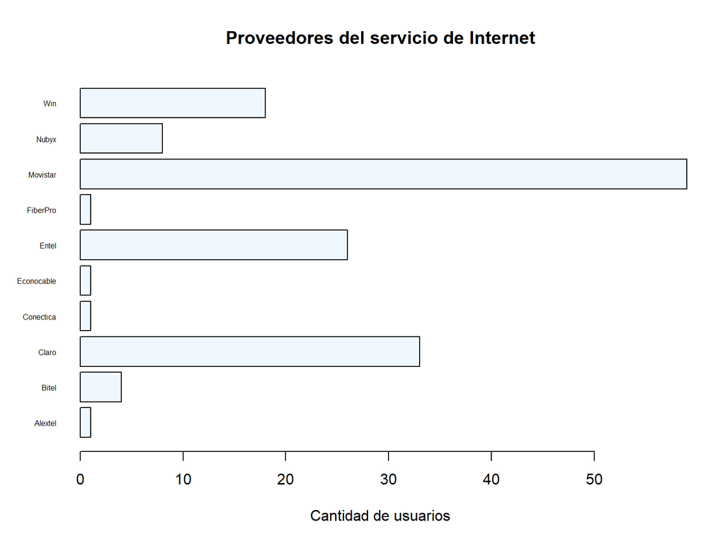

**Observaciones**

En la gráfica mostrar que el servicio más usado es el que brinda Movistar, seguido de Claro y Entel, mientras que los demás tienen una menor cantidad de usuarios.

#### *Variable PAGO_MENSUAL:*

En esta variable se mostrará cuánto pagan por tener el servicio a Internet.

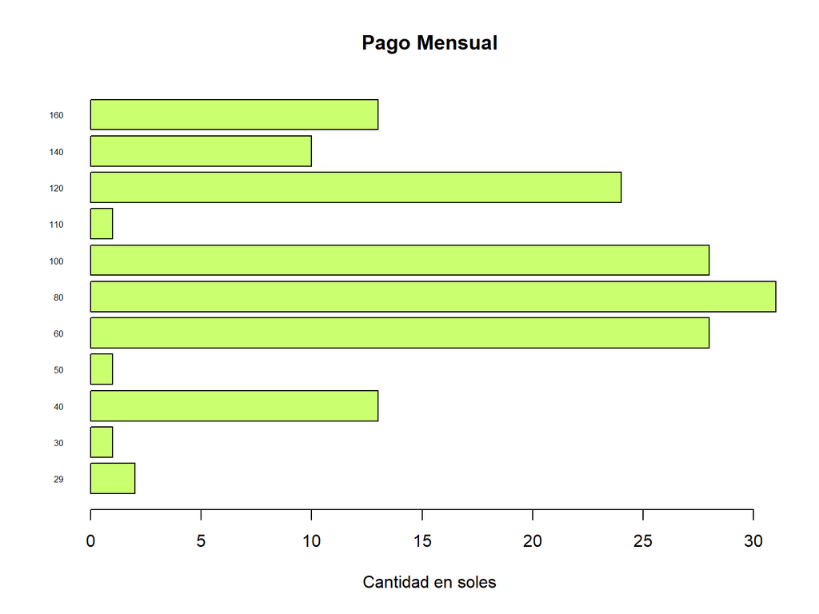

**Observaciones**

#### *Variable HORAS_DE_USO:*

En este gráfico se mostrará cuántas horas promedio al día usan el Internet nuestro encuestados.

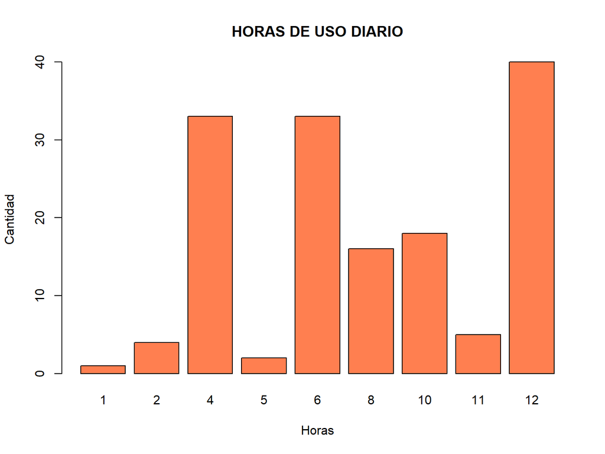

**Observaciones**

#### *Variable CONSIDERACION:*

En este gráfico se mostrará cuál es la percepción que tienen los encuestados respecto a su conexión a Internet, siendo esta desde muy mala hasta muy buena.

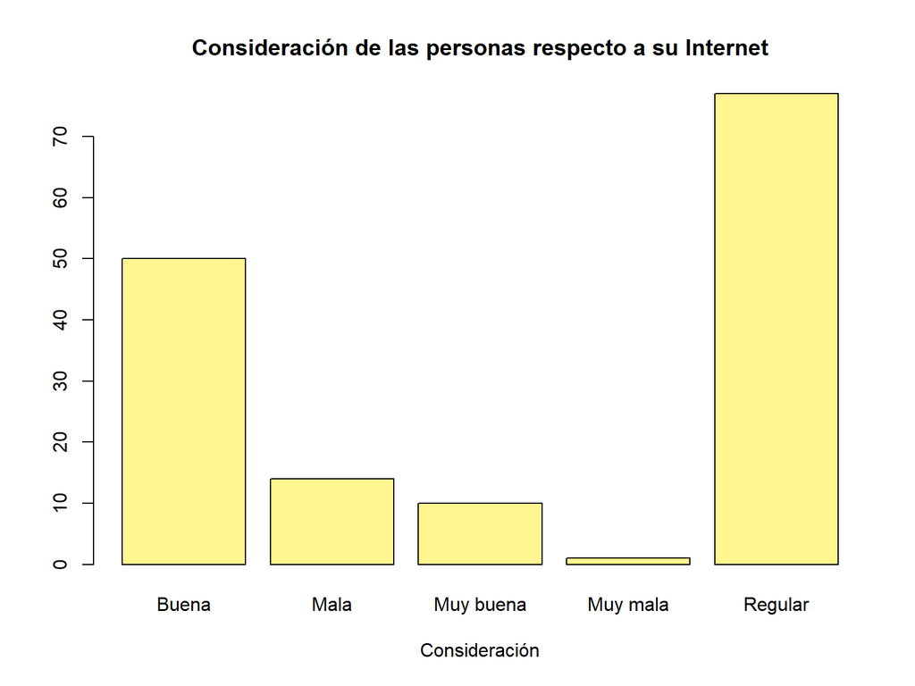

**Observaciones**

En el gráfico se puede observar que la mayoría piensa que su Internet es regular en sus hogares.

#### *Variable USO:*

En este gráfico se mostrará cuales son las actividades más frecuentes para las que las personas usan el Internet.

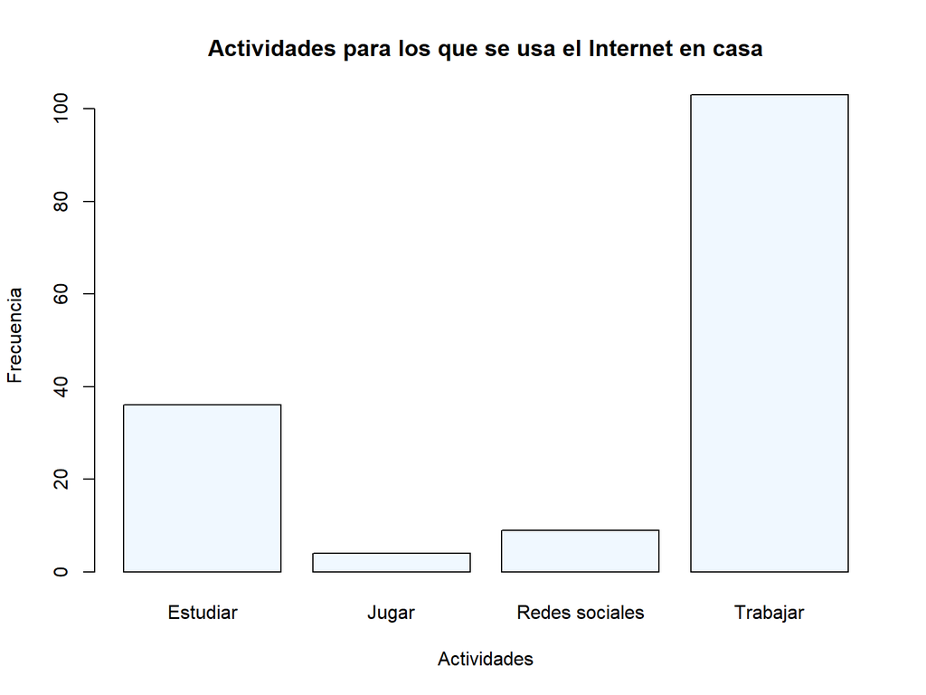

**Observaciones**

**Observaciones**

#### *Variable FAMILIARES_WIFI:*

En este gráfico de barras se mostrará cuántos familiares prefieren usar WIFI y no datos móviles.

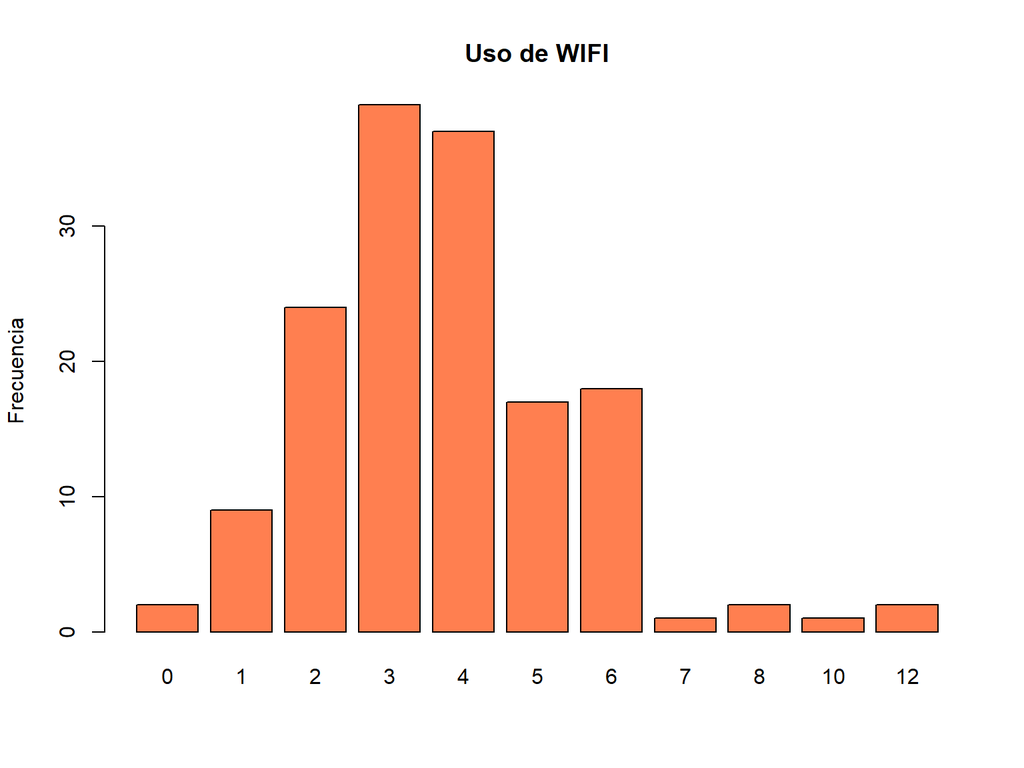

**Observaciones**

Podemos Observar en el gráfico de barras en promedio de 4 personas en cada hogar prefiere usar WIFI.

#### *Variable FAMILIARES_DATOS:*

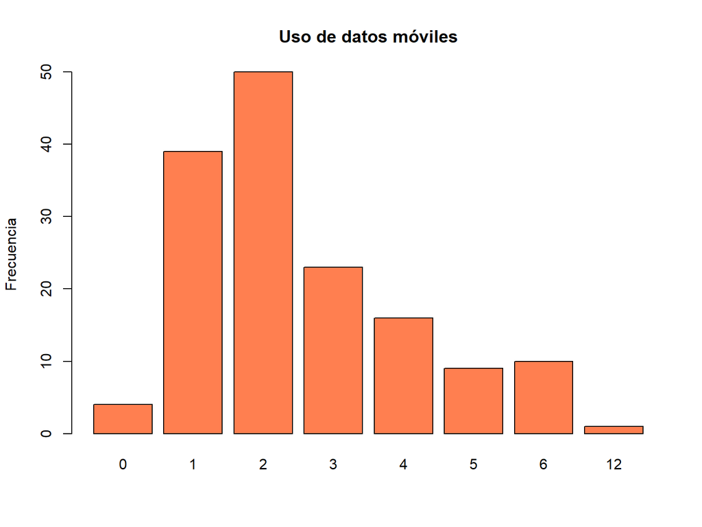

**Observaciones**

#### *Variable PERSONAS_TOTAL:*

En este gráfico de barras se mostrará cuantas personas usan al mismo tiempo la red WIFI en cada hogar de los encuestados.

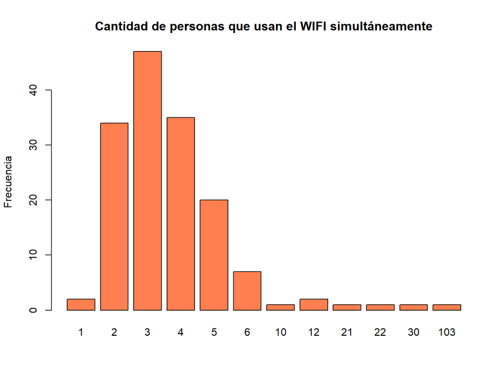

**Observaciones**

Podemos Observar en que cerca de 4 personas usan la red WIFI simultáneamente.

#### *Variable VEL_CAR_OFREC :*

En este gráfico queremos ver cuántos MPBS de subida es lo que ofrecen las empresas en MBPS.

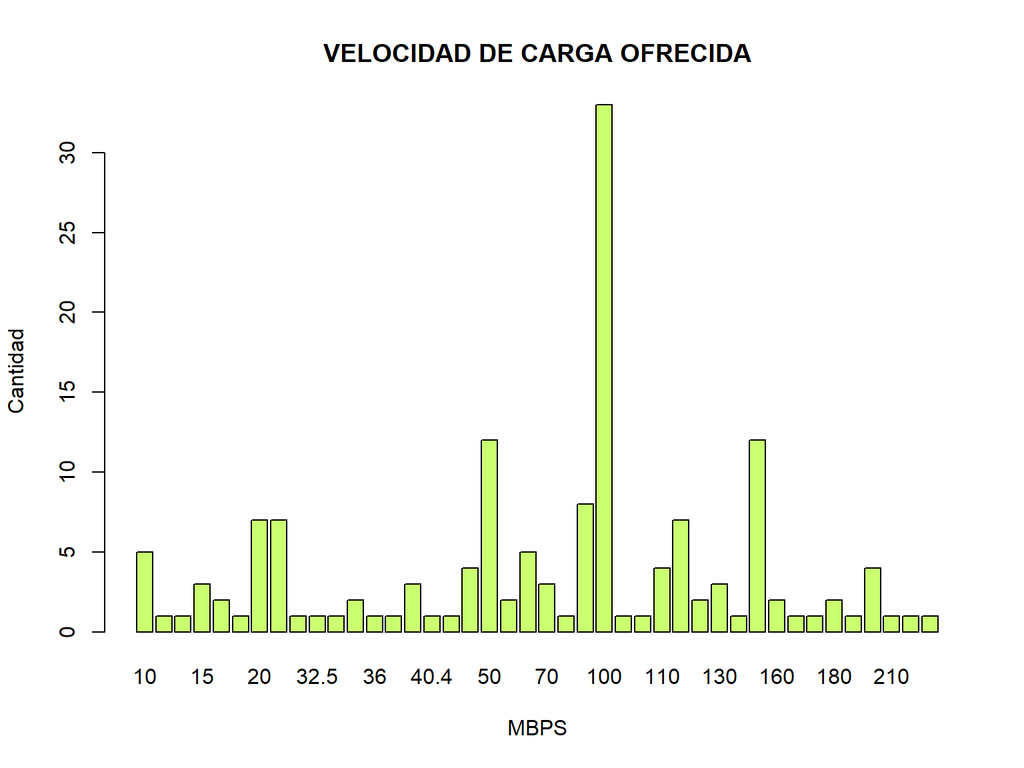

**Observaciones**

#### *Variable VEL_DES_OFREC :*

En este gráfico queremos ver cuántos MBPS de bajada es lo que ofrecen las empresas en MBPS.

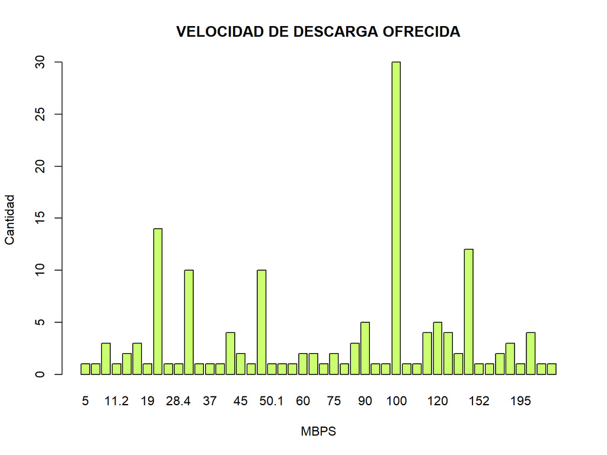

**Observaciones**

Podemos observar que la mayoría de clientes solicitan un Internet entre 70 y 140 Mbps, de bajada por lo que es lo que la mayoría de personas debería de recibir.

#### *Variable VEL_CAR_REAL :*

Con este gráfico, vamos a poder comparar si lo observado en la gráfica de carga ofrecida es lo que realmente llega como señal a los hogares.

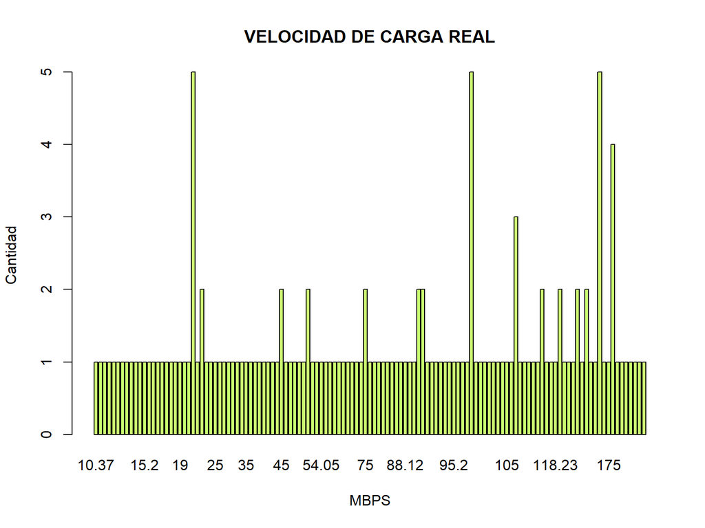

**Observaciones**

Podemos observar que la mayoría de clientes no recibe realmente lo que solicitan,a excepción de unos casos.

#### *Variable VEL_DES_REAL :*

Con este gráfico, vamos a poder comparar si lo observado en la gráfica de descarga ofrecida es lo que realmente llega como señal a los hogares.

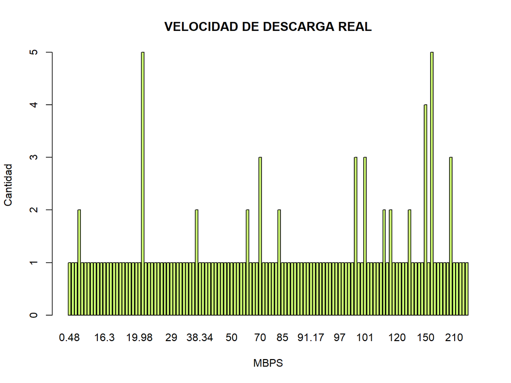

**Observaciones**

#### *Variable VEL_ENTREG:*

En esta variable se usará un gráfico de barras horizontal y se mostrará con respecto a los 4 gráficas anteriores si es que lo que las compañías dan en MBPS es mucho más o mucho menos de lo que ofrecen.

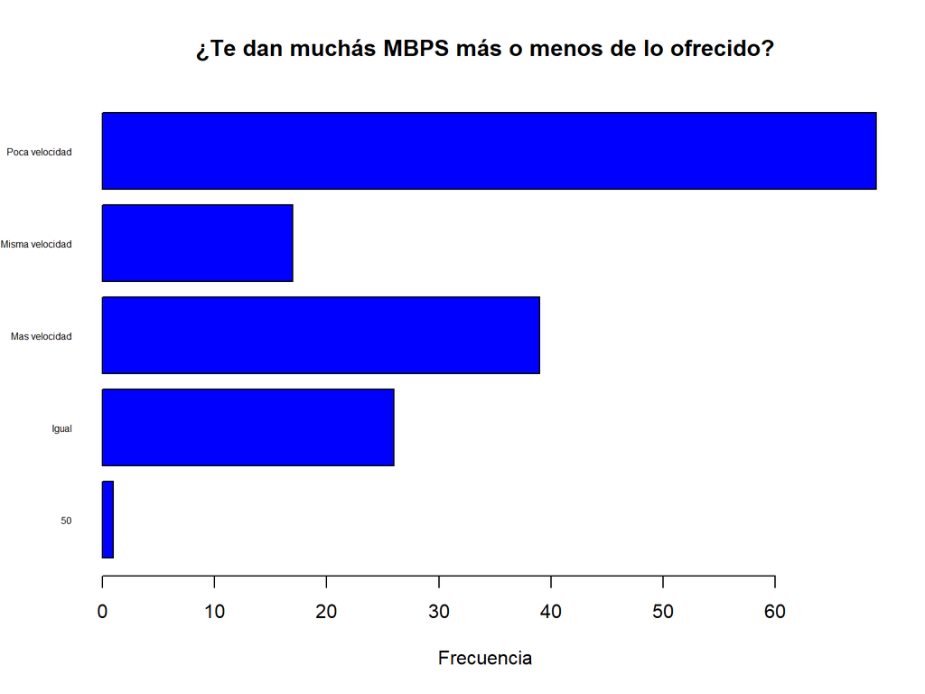

**Observaciones**

#### *Variable IMPORTANCIA:*

En esta gráfica veremos cuán importante es el Internet en la vida de las personas desde su percepción.

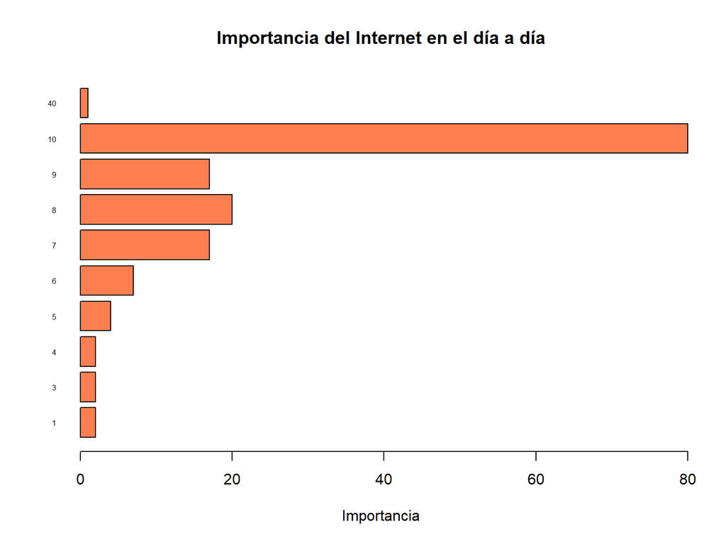

**Observaciones**

#### *Variable PROBLEMAS:*

En esta gráfica veremos cuales son los principales problemas que se presentan al usar el Internet.

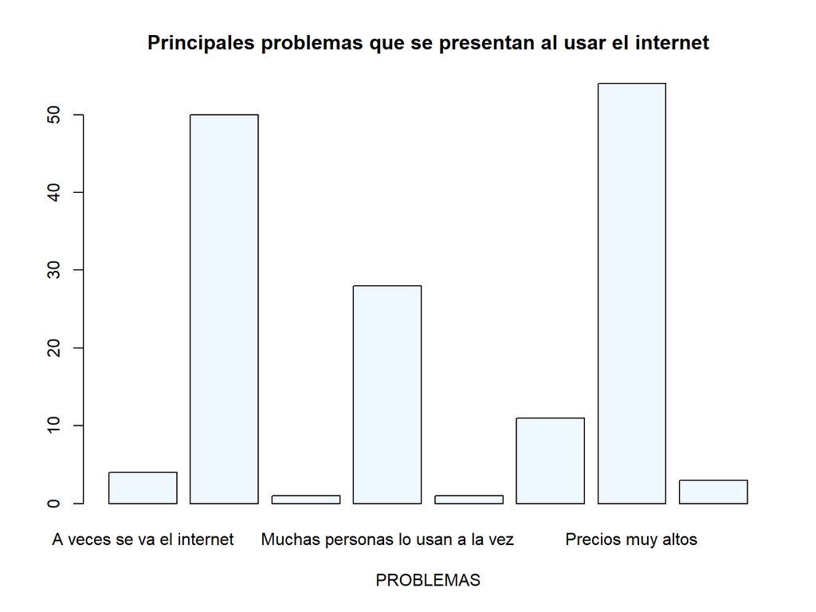

**Observaciones**

#### *Variable PELI_PERS:*

En este gráfico mostraremos cuánto demora en descargar una película en la casa del encuestado, creemos que esto nos servirá para ver que tan rápido se puede navegar en el Internet.

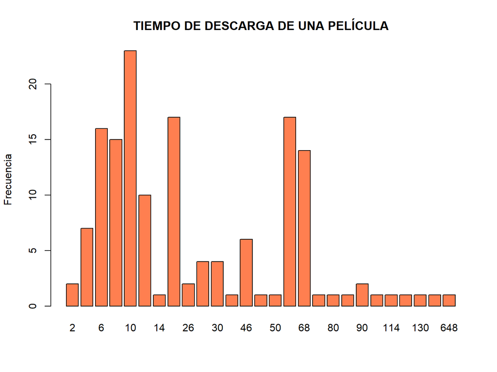

**Observaciones**

#### *Variable PELI_VEC:*

En este gráfico mostraremos cuánto demora en descargar una película en la casa de un vecino del encuestado, creemos que esto nos servirá para ver que tan rápido se puede navegar en el Internet con otra compañía.

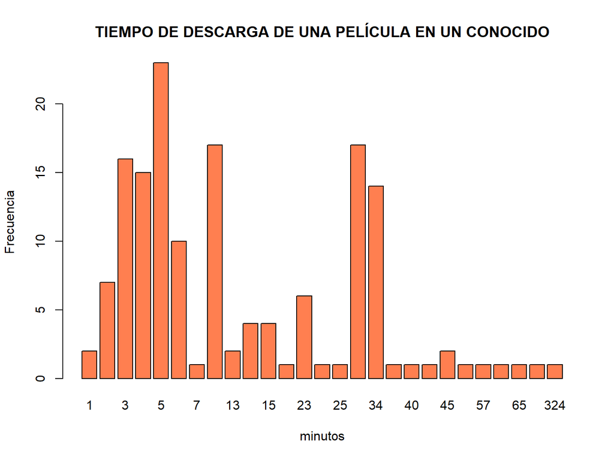

**Observaciones**

#### *Variable FALLAS_4_SEM*

En esta gráfica veremos cuántas fallas en el Internet, en promedio, se ha podido evidenciar durante las últimas 4 semanas.

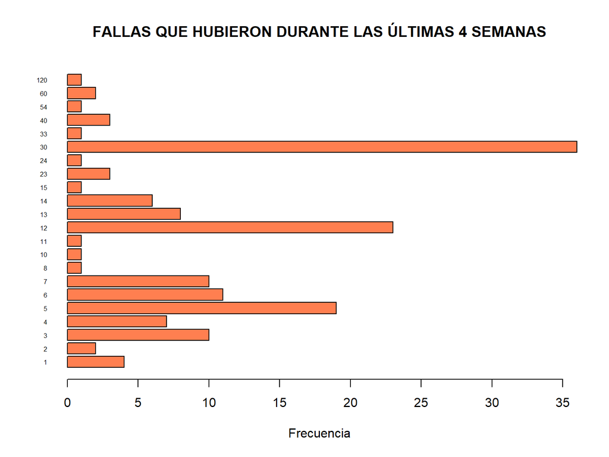

**Observaciones**

#### *Variable TIEM_ATEN*

En esta gráfica queremos presentar cuánto se demoraron en atender una llamada telefónica al reportar una falla con la conexión Internet.

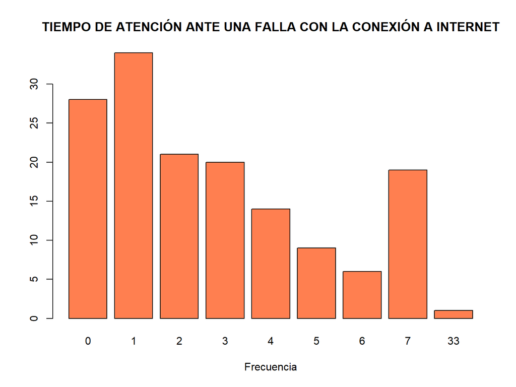

**Observaciones**

Como se puede ver el promedio está entre 1 y 5 min, lo que no sería mucho tiempo, considerando que las compañías pueden recibir muchas llamas simultáneas.

#### *Variable TIEM_ARREG*

En esta gráfica queremos presentar cuánto tiempo se tardaron en arreglar la falla técnica que se tuvo.

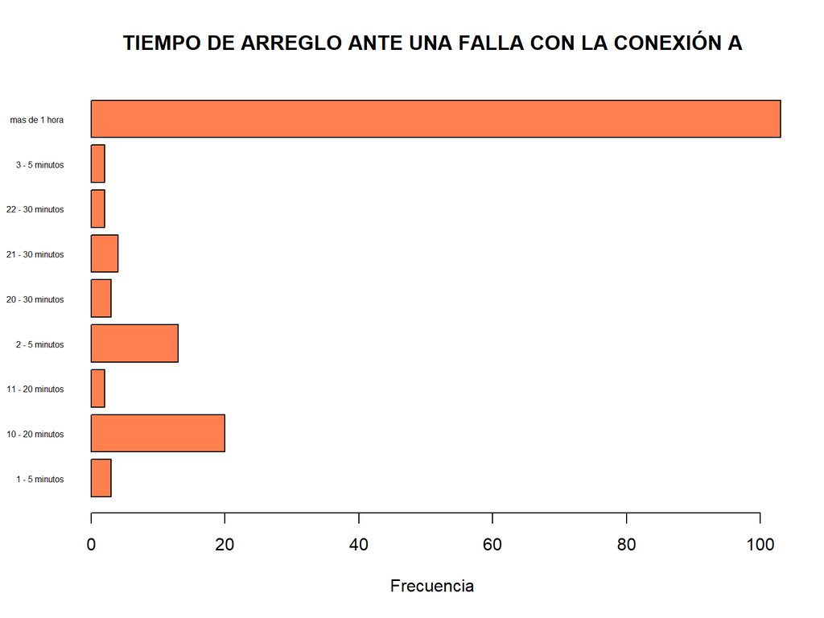

**Observaciones**

#### *Variable CAMBIOS:*

En esta gráfica vemos cuántas veces se han tenido que cambiar de empresa buscando una mejor conexión.

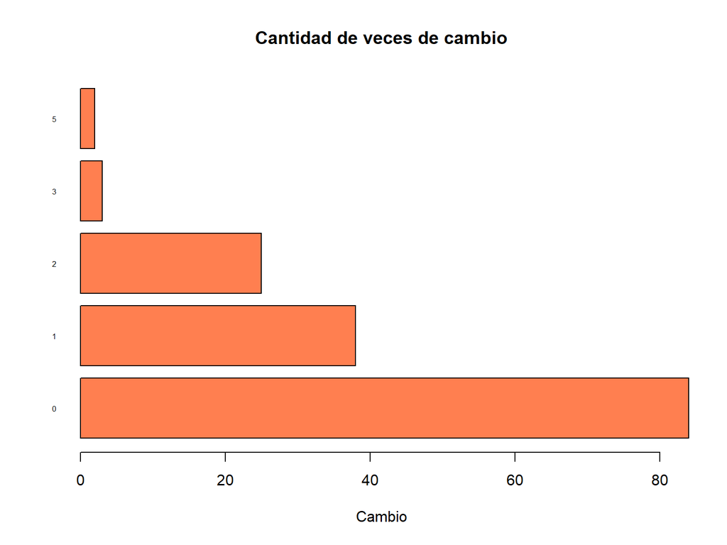

**Observaciones**

Se puede ver que a pesar de los problemas la mayoría solo se ha cambiado 1 vez o nunca en toda su vida.

### **Variables Agregadas**

#### **Variable COMPA_CARGAS**

Para esta variable queremos realizar una comparación entre las variables de carga real y carga ofrecida, para observar cuánta es la diferencia.

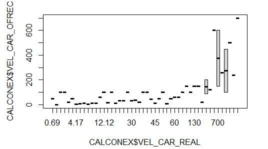

**Observaciones**

Como vemos la diferencia de la carga ofrecida y la real es notoria, por lo que esto sería una estafa de parte de las empresas a los clientes.

#### **Variable COMPA_DESCARGAS**

Para esta variable queremos realizar una comparación entre las variables de descarga real y descarga ofrecida, para observar cuánta es la diferencia.

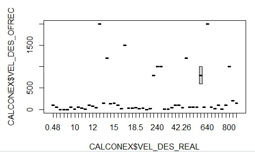

**Observaciones**

Como vemos la diferencia de la descarga ofrecida y la real es bastante notoria, por lo que esto se consideraría una estafa de parte de las empresas a los clientes.

# 6. PREGUNTAS DE LA ENCUESTA

- Nombres
- Edad
- ¿De qué distrito eres?
- ¿Con qué tipo de acceso a Internet cuenta?
- ¿Qué proveedor de Internet usas?
- ¿Cuánto pagas al mes por el servicio de Internet?
- ¿Cuántas horas al día usa el Internet?
- ¿Cómo considera que es su conectividad a Internet?
- ¿Para que usan Internet?
- ¿Con que dispositivos usas más el Internet?
- ¿Cuántos familiares usan la red Wi-fi?
- ¿Cuántos familiares utilizan datos?
- ¿Cuántas personas en total usan el Internet simultáneamente en tu casa?
- ¿Cuál es la velocidad de carga(subida) que le ofrecieron?
- ¿Cuál es la velocidad de descarga (bajada) le ofrecieron?
- ¿Qué velocidad de descarga (bajada) tiene usted en realidad?
- ¿Qué velocidad de carga(subida) tiene usted en realidad?
- ¿podría decirme si su compañía proveedora le entrega menos velocidad de la prometida?
- ¿Cuán importante crees que es el uso de Internet e tu vida diaria?
- ¿Qué tipos de problemas tienes con tu Internet?
- ¿Cuánto tiempo le toma a usted descargar una película vía Internet?
- ¿Cuánto tiempo cree que le toma a sus amigos del barrio de otro proveedor de Internet a descargar una película?
- ¿Cuántas veces se ha interrumpido el servicio de Internet durante las últimas 4 semanas aproximadamente?
- Cuánto tiempo llamó para reportar el inconveniente, ¿Cuánto demoraron en atenderlo(a)?
- ¿Cuánto tardó en ir un técnico a su hogar?
- ¿Cuántas veces se ha cambiado de compañía tratando de resolver los problemas de conexión?

# 7. CONCLUSIONES DE LA ENTREGA P1

De la encuesta, investigación y todos los gráficos que hemos realizado hasta ahora, podemos decir que si se evidencia un problema con la calidad de Conexión que se tiene en los hogares, algunos de los motivos que podemos deducir (ya que el estudio aún no esta terminado), es la cantidad de personas que lo usan, pero podemos decir que el mayor problema es que las empresas no cumplen con lo que prometen, esto trae problemas ya que también hemos podido ver que el uso del Internet es de suma importancia para las personas, ya que hoy en día se utiliza para casi todo lo que realizamos, debido a la pandemia y que muchos estudian y trabajan desde casa. Esperamos seguir avanzando en nuestro estudio y poder tener una conclusión más concreta.

P2

# 1. CORRECCIONES DE LA ENTREGA ANTERIOR

En esta entrega, consideramos agregar más descriptores numéricos que en la entrega anterior faltaron, a su vez agregamos gráficos más exactos que en la primera entrega, ya que esta vez trabajamos con una base de datos de 152 personas encuestadas de los 5 distritos en los que nos enfocamos.

Tratamos de limpiar la encuesta lo mejor posible, además que la encuesta fue muy puntual por lo que no hubo mucho que mejorar.

# **2. Variables**

### **Variables de Encuesta ‘CALIDAD DE CONEXIÓN’**

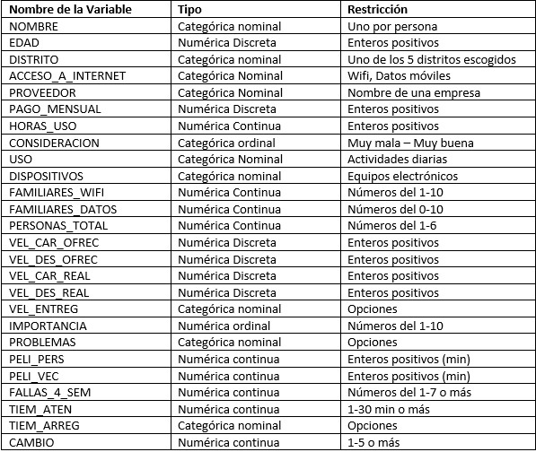

# **3. Descriptores numéricos y gráficos**

# Cantidad de encuestados / Observaciones

En esta variable podemos ver cual es la cantidad de personas que hemos logrado encuestar hasta el momento, siendo en total 152 entre mujeres y varones de distintas edades, de los 5 distritos en los que nos enfocamos

```r
length(CALIDCONEX$NOMBRE)
```

```
## [1] 152
```

Cantidad de variables Aquí podemos ver la cantidad de variables que pudimos obtener de nuestra encuesta con las diferentes preguntas que realizamos.

```r
length(CALIDCONEX)
```

```
## [1] 26
```

Descriptores numéricos según edades aqui observamos la media, mediana y cuartiles de las edades que respondieron nuestra encuesta, que la media es alrededor de 22 años.

```r
summary(CALIDCONEX$EDAD)
```

```
##    Min. 1st Qu.  Median    Mean 3rd Qu.    Max.
##   15.00   19.00   20.00   22.32   23.00   59.00
```

Observamos que la mediana de las edades es de 20 años, obteniendo como edad mínima 15 años y edad máxima de 59 años

### **Variables Categóricas**

#### **Variable Distrito**

Para esta variable se realiza un diagrama de barras, para observar aproximadamente cuantas personas respondieron de cada distrito.

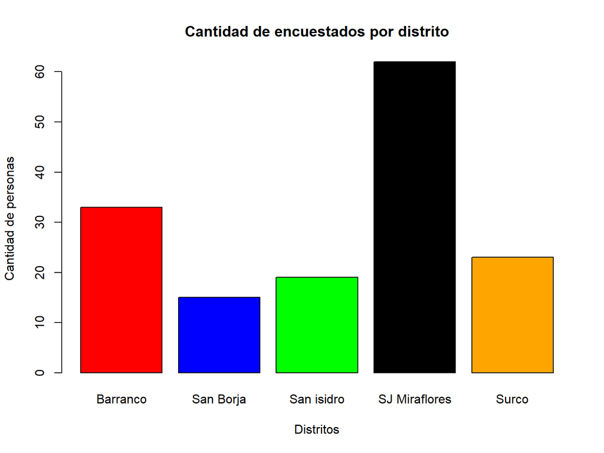

**Observaciones**

La gráfica de barras nos revela que tenemos más encuestados de San Juan de Miraflores, siguiéndole el distrito de barranco, mientras que en San Borja, tenemos la menor cantidad de personas encuestadas.

#### *Variable ACCESO A INTERNET:*

Para esta variable se realizará un gráfico de barras para visualizar cuántas personas usan WIFI o datos móviles en prepago y postpago.

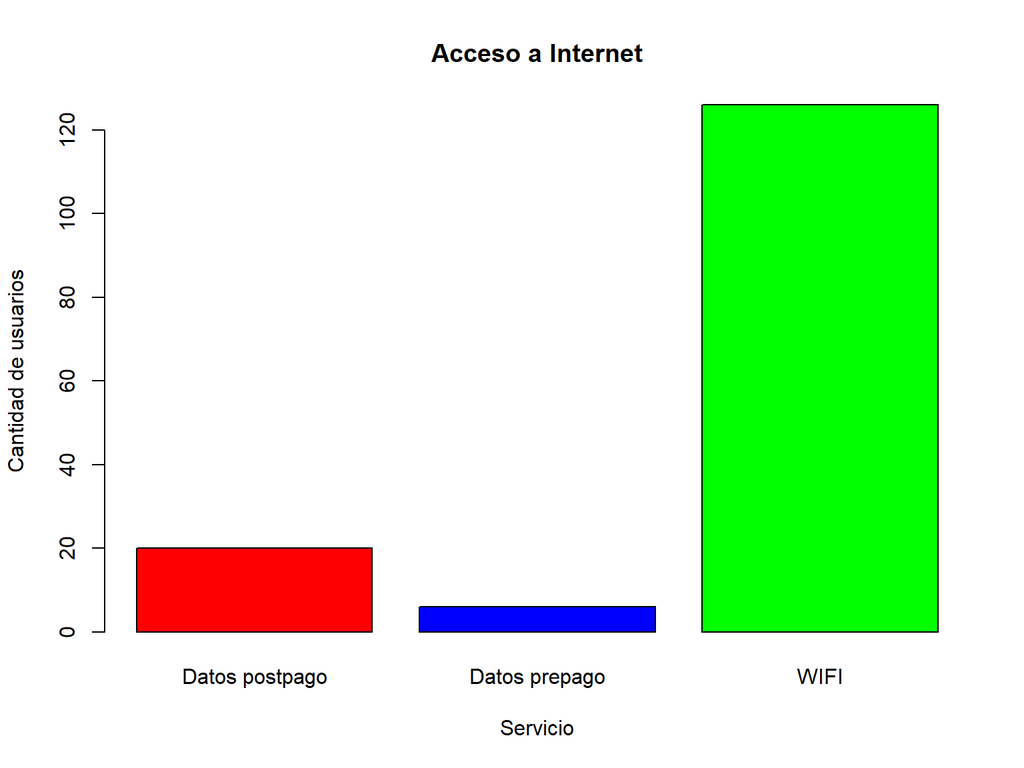

En el gráfico se puede observar claramente que la mayoría se conecta mediante la red WIFI en sus hogares.

#### *Variable PROVEEDOR:*

En esta variable se realizará una gráfica de barras para conocer cual es el proveedor más usado que ofrece el servicio a Internet.

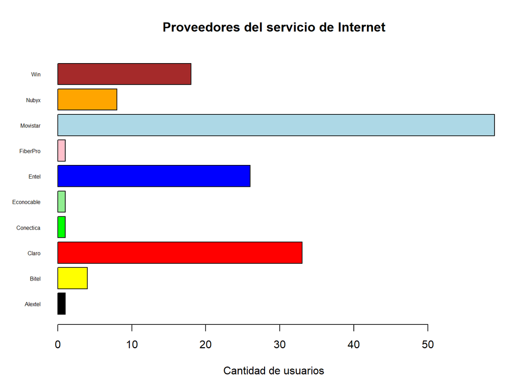

**Observaciones**

En la gráfica mostrada, el servicio más usado es el proveedor Movistar, seguido de Claro y Entel, mientras que los demás tienen una menor cantidad de usuarios como se observa con Econocable y Fiberpro.